# Lab 3

Peter Gansallo

2024-10-24

Install the necessary libraries

```r
# Load the necessary tools and setting the work directory
install.packages("Hmisc", repos = "http://cran.us.r-project.org")
install.packages("descr", repos = "http://cran.us.r-project.org")
install.packages("readxl") # to read excel files
```

Load the necessary libraries and set path

```r
library(readxl)
library(tidyverse) # collection of R packages designed for data science
library("Hmisc")
library("descr")
library(devtools)
library(here) # helps with filepaths
library(dplyr)
setwd("~/Desktop/RWork")
here::i_am("lab3_modified.Rmd") # this should match the file name
```

## Report 1.1

I’ve decided to use the cpsaat07 dataset from the BLS which shows unemployment rates and education level, and all of this data from BLS can be accessed here https://www.bls.gov/cps/tables.htm

Load BLS cpsaat07 datasets (Unemployment by Education)

```r
edu_2017 <- read_excel("cpsaat07_2017.xlsx")
edu_2018 <- read_excel("cpsaat07_2018.xlsx")
edu_2019 <- read_excel("cpsaat07_2019.xlsx")
edu_2020 <- read_excel("cpsaat07_2020.xlsx")
edu_2021 <- read_excel("cpsaat07_2021.xlsx")
edu_2022 <- read_excel("cpsaat07_2022.xlsx")
edu_2023 <- read_excel("cpsaat07_2023.xlsx")
```

## Report 1.2

I’ll be analyzing these variables: - Education level determining skill category and unemployment rates - Unemployment_rate over time

### Bivariate Analysis on:

- Skill Category and Unemployment Rates: This analysis will examine how unemployment varies across skill levels, providing insights into which skill categories are most affected. -Unemployment Rates over time: This will show show how unemployment trends have changed over time

## Report 1.3

How do unemployment rates vary across skill categories (Low, Medium, High), and are low-skill workers more negatively impacted by economic or technological changes?

## Report 1.4

After we loading the cpsaat07 datasets from the BLS we’ll begin with cleaning and organizing the data. Empty rows will be removed, column names will be renamed, being “less than high_school”, “high school”, etc, then those columns will be collapsed into one column called education level column called education. A year column will be added to associate the data with its respective year. Education levels will then be categorized into skill levels.

## Report 1.5

I’m only the years of 2017–2023, which is relatively a short time frame that may not capture long-term trends or the gradual impacts of automation and AI adoption. This period also includes the COVID-19 pandemic, a economic disruption that could disproportionately influence results, limiting its generalizability. The Pearson correlation test can reveal trends over time, it assumes a linear relationship, which may not accurately reflect unemployment dynamics.

Collapsing education levels into skill categories simplifies the analysis but may mask variations within each category. The absence of direct data on AI adoption or automation trends also limits the ability to link findings to technological changes. Expanding the time frame or incorporating industry-specific data would also provide deeper insights.

# Part 2

## Report 1.6

There aren’t necessarily any missing data, however the way the BLS formatted the data set there are so spaces(empty rows in the data set) so I’ll just remove those rows, but every education level has a corresponding unemployment number

## Report 1.7

### Clean up CPSAAT07 data

Inspect the education/unemployment data

```r
#View(edu_2023)
colnames(edu_2023)
```

```
## [1] "HOUSEHOLD DATA\r\nANNUAL AVERAGES\r\n7. Employment status of the civilian noninstitutional population 25 years and over by educational attainment, sex, race, and Hispanic or Latino ethnicity"
## [2] "...2"
## [3] "...3"
## [4] "...4"
## [5] "...5"
## [6] "...6"
## [7] "...7"
## [8] "...8"
## [9] "...9"
```

After viewing the data set we in R it’s very messy

Clean edu 2023

```r
edu_2023 <- edu_2023 %>%
  rename(unemployed = "HOUSEHOLD DATA\r\nANNUAL AVERAGES\r\n7. Employment status of the civilian noninstitutional population 25 years and over by educational attainment, sex, race, and Hispanic or Latino ethnicity") %>%
  filter(unemployed == "Unemployment rate") %>%
  rename(less_highschool = "...2") %>%
  rename(highschool_no_college = "...3") %>%
  rename(some_college_no_degree = "...5") %>%
  rename(associaate_degree = "...6") %>%
  rename(bachelor_degree = "...8") %>%
  rename(advanced_degree = "...9")
```

Inspect updated data

```r
str(edu_2023)
```

```
## tibble [7 × 9] (S3: tbl_df/tbl/data.frame)
##  $ unemployed            : chr [1:7] "Unemployment rate" "Unemployment rate" "Unemployment rate" "Unemployment rate" ...
##  $ less_highschool       : chr [1:7] "5.6" "5.0999999999999996" "6.4" "5.0999999999999996" ...
##  $ highschool_no_college : chr [1:7] "3.9" "4" "3.8" "3.4" ...
##  $ ...4                  : chr [1:7] "3" "3.1" "3" "2.7" ...
##  $ some_college_no_degree: chr [1:7] "3.3" "3.3" "3.3" "2.9" ...
##  $ associaate_degree     : chr [1:7] "2.7" "2.9" "2.6" "2.4" ...
##  $ ...7                  : chr [1:7] "2.1" "2.1" "2" "1.9" ...
##  $ bachelor_degree       : chr [1:7] "2.2000000000000002" "2.2000000000000002" "2.2000000000000002" "2.1" ...
##  $ advanced_degree       : chr [1:7] "1.8" "1.9" "1.8" "1.7" ...
```

Keep only the columns of interest and collapse columns into one column education https://www.geeksforgeeks.org/extract-first-n-rows-from-dataframe-in-r/

Remember that also the rows are broken down into more categories on ethnicity/race/gender The first row of this data are the total numbers which we’ll be looking at so we’ll filter that

```r
# Remove columns that don't correspond to education levels
edu_2023 <- edu_2023 %>%
  select(-unemployed, -`...4`, -`...7`)

# Create a new data frame with education, unemployment_rate, and year
edu_2023 <- data.frame(
  education = colnames(edu_2023),
  unemployment_rate = as.numeric(edu_2023[1, ]), # Extract the first row
  year = 2023
)
```

Look at updated edu 2023 and make sure it still matches data from BLS

```r
#View(edu_2023)
str(edu_2023)
```

```
## 'data.frame':    6 obs. of  3 variables:
##  $ education        : chr  "less_highschool" "highschool_no_college" "some_college_no_degree" "associaate_degree" ...
##  $ unemployment_rate: num  5.6 3.9 3.3 2.7 2.2 1.8
##  $ year             : num  2023 2023 2023 2023 2023 ...
```

#### Do the same for the rest of the CPSAAT07 data

Clean 2022

```r
edu_2022 <- edu_2022 %>%
  rename(unemployed = "HOUSEHOLD DATA\r\nANNUAL AVERAGES\r\n7. Employment status of the civilian noninstitutional population 25 years and over by educational attainment, sex, race, and Hispanic or Latino ethnicity") %>%
  filter(unemployed == "Unemployment rate") %>%
  rename(less_highschool = "...2") %>%
  rename(highschool_no_college = "...3") %>%
  rename(some_college_no_degree = "...5") %>%
  rename(associaate_degree = "...6") %>%
  rename(bachelor_degree = "...8") %>%
  rename(advanced_degree = "...9")

# Remove columns that don't correspond to education levels
edu_2022 <- edu_2022 %>%
  select(-unemployed, -`...4`, -`...7`)

# Create a new data frame with education, unemployment_rate, and year
edu_2022 <- data.frame(
  education = colnames(edu_2022),
  unemployment_rate = as.numeric(edu_2022[1, ]), # Extract the first row
  year = 2022)
```

Clean 2021

```r
edu_2021 <- edu_2021 %>%
  rename(unemployed = "HOUSEHOLD DATA\r\nANNUAL AVERAGES\r\n7. Employment status of the civilian noninstitutional population 25 years and over by educational attainment, sex, race, and Hispanic or Latino ethnicity") %>%
  filter(unemployed == "Unemployment rate") %>%
  rename(less_highschool = "...2") %>%
  rename(highschool_no_college = "...3") %>%
  rename(some_college_no_degree = "...5") %>%
  rename(associaate_degree = "...6") %>%
  rename(bachelor_degree = "...8") %>%
  rename(advanced_degree = "...9")

# Remove columns that don't correspond to education levels
edu_2021 <- edu_2021 %>%
  select(-unemployed, -`...4`, -`...7`)

# Create a new data frame with education, unemployment_rate, and year
edu_2021 <- data.frame(
  education = colnames(edu_2021),
  unemployment_rate = as.numeric(edu_2021[1, ]), # Extract the first row
  year = 2021)
```

Clean 2020

```r
edu_2020 <- edu_2020 %>%
  rename(unemployed = "HOUSEHOLD DATA\r\nANNUAL AVERAGES\r\n7.  Employment status of the civilian noninstitutional population 25 years and over by educational attainment, sex, race, and Hispanic or Latino ethnicity") %>%
  filter(unemployed == "Unemployment rate") %>%
  rename(less_highschool = "...2") %>%
  rename(highschool_no_college = "...3") %>%
  rename(some_college_no_degree = "...5") %>%
  rename(associaate_degree = "...6") %>%
  rename(bachelor_degree = "...8") %>%
  rename(advanced_degree = "...9")

# Remove columns that don't correspond to education levels
edu_2020 <- edu_2020 %>%
  select(-unemployed, -`...4`, -`...7`)

# Create a new data frame with education, unemployment_rate, and year
edu_2020 <- data.frame(
  education = colnames(edu_2020),
  unemployment_rate = as.numeric(edu_2020[1, ]), # Extract the first row
  year = 2020)
```

Clean 2019

```r
edu_2019 <- edu_2019 %>%
  rename(unemployed = "HOUSEHOLD DATA\r\nANNUAL AVERAGES\r\n7.  Employment status of the civilian noninstitutional population 25 years and over by educational attainment, sex, race, and Hispanic or Latino ethnicity") %>%
  filter(unemployed == "Unemployment rate") %>%
  rename(less_highschool = "...2") %>%
  rename(highschool_no_college = "...3") %>%
  rename(some_college_no_degree = "...5") %>%
  rename(associaate_degree = "...6") %>%
  rename(bachelor_degree = "...8") %>%
  rename(advanced_degree = "...9")

# Remove columns that don't correspond to education levels
edu_2019 <- edu_2019 %>%
  select(-unemployed, -`...4`, -`...7`)

# Create a new data frame with education, unemployment_rate, and year
edu_2019 <- data.frame(
  education = colnames(edu_2019),
  unemployment_rate = as.numeric(edu_2019[1, ]), # Extract the first row
  year = 2019)
```

Clean 2018

```r
edu_2018 <- edu_2018 %>%
  rename(unemployed = "HOUSEHOLD DATA\r\nANNUAL AVERAGES\r\n7. Employment status of the civilian noninstitutional population 25 years and over by educational attainment, sex, race, and Hispanic or Latino ethnicity") %>%
  filter(unemployed == "Unemployment rate") %>%
  rename(less_highschool = "...2") %>%
  rename(highschool_no_college = "...3") %>%
  rename(some_college_no_degree = "...5") %>%
  rename(associaate_degree = "...6") %>%
  rename(bachelor_degree = "...8") %>%
  rename(advanced_degree = "...9")

# Remove columns that don't correspond to education levels
edu_2018 <- edu_2018 %>%
  select(-unemployed, -`...4`, -`...7`)

# Create a new data frame with education, unemployment_rate, and year
edu_2018 <- data.frame(
  education = colnames(edu_2018),
  unemployment_rate = as.numeric(edu_2018[1, ]), # Extract the first row
  year = 2018)
```

Clean 2017

```r
edu_2017 <- edu_2017 %>%
  rename(unemployed = "HOUSEHOLD DATA\r\nANNUAL AVERAGES\r\n7.  Employment status of the civilian noninstitutional population 25 years and over by educational attainment, sex, race, and Hispanic or Latino ethnicity") %>%
  filter(unemployed == "Unemployment rate") %>%
  rename(less_highschool = "...2") %>%
  rename(highschool_no_college = "...3") %>%
  rename(some_college_no_degree = "...5") %>%
  rename(associaate_degree = "...6") %>%
  rename(bachelor_degree = "...8") %>%
  rename(advanced_degree = "...9")

# Remove columns that don't correspond to education levels
edu_2017 <- edu_2017 %>%
  select(-unemployed, -`...4`, -`...7`)

# Create a new data frame with education, unemployment_rate, and year
edu_2017 <- data.frame(
  education = colnames(edu_2017),
  unemployment_rate = as.numeric(edu_2017[1, ]), # Extract the first row
  year = 2017)
```

Combine the CPSAAT07 datasets, for the time comparison as well

```r
education_unemployment <- bind_rows(edu_2017,
                        edu_2018,
                        edu_2019,
                        edu_2020,
                        edu_2021,
                        edu_2022,
                        edu_2023) %>%
  na.omit() %>%
  droplevels()
```

### Categorize education in skill levels

Low Skill: Representing minimal formal education and qualifying for routine or manual labor jobs. - Less than High school (No high school diploma) - High School (No College)

Medium Skill: Reflects intermediate training or post-secondary education suited for administrative or skilled technical roles. - Some College (No Degree) - Associate’s Degree

High Skill: Representing higher education levels normally associated with professional or highly technical roles. - Bachelor’s Degree - Advanced Degree (Master’s, PHD)

```r
education_unemployment <- education_unemployment %>%
  mutate(skill_category = fct_recode(education,

                    #Low skill
    "Low Skill" = "less_highschool",
    "Low Skill" = "highschool_no_college",

                    #Medium skill
    "Medium Skill" = "some_college_no_degree",
    "Medium Skill" = "associaate_degree",


                    #High skill
    "High Skill" = "bachelor_degree",
    "High Skill" = "advanced_degree"
  ))
```

## Report 1.8

### Analysis

take a look at the data

```r
head(education_unemployment)
```

```
##                education unemployment_rate year skill_category
## 1        less_highschool               6.5 2017      Low Skill
## 2  highschool_no_college               4.6 2017      Low Skill
## 3 some_college_no_degree               4.0 2017   Medium Skill
## 4      associaate_degree               3.4 2017   Medium Skill
## 5        bachelor_degree               2.5 2017     High Skill
## 6        advanced_degree               2.0 2017     High Skill
```

```r
tail(education_unemployment)
```

```
##                 education unemployment_rate year skill_category
## 37        less_highschool               5.6 2023      Low Skill
## 38  highschool_no_college               3.9 2023      Low Skill
## 39 some_college_no_degree               3.3 2023   Medium Skill
## 40      associaate_degree               2.7 2023   Medium Skill
## 41        bachelor_degree               2.2 2023     High Skill
## 42        advanced_degree               1.8 2023     High Skill
```

```r
summary(education_unemployment)
```

```
##   education         unemployment_rate      year           skill_category
##  Length:42          Min.   : 1.700    Min.   :2017   High Skill  :14
##  Class :character   1st Qu.: 2.550    1st Qu.:2018   Medium Skill:14
##  Mode  :character   Median : 3.700    Median :2020   Low Skill   :14
##                     Mean   : 4.229    Mean   :2020
##                     3rd Qu.: 5.500    3rd Qu.:2022
##                     Max.   :11.700    Max.   :2023
```

```r
summary(education_unemployment$unemployment_rate)
```

```
##    Min. 1st Qu.  Median    Mean 3rd Qu.    Max.
##   1.700   2.550   3.700   4.229   5.500  11.700
```

#### Compare the relationship between skill category and unemployment

Unemployment rate and Skill Category by education

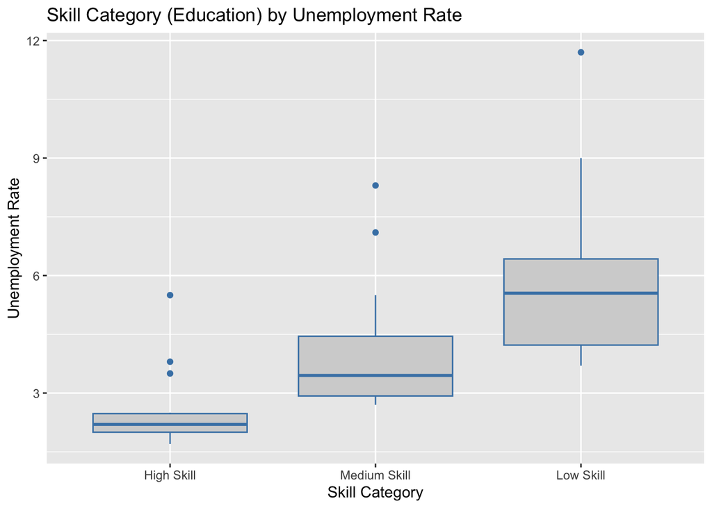

```r
# Box plot of unemployment by skill category
ggplot(education_unemployment, aes(x = skill_category, y = unemployment_rate)) +
  geom_boxplot(fill = "lightgray", color = "steelblue") +
  labs(x = "Skill Category", y = "Unemployment Rate") +
  ggtitle("Skill Category (Education) by Unemployment Rate")
```

Unemployment by skill category (education) (Look at the distribution)

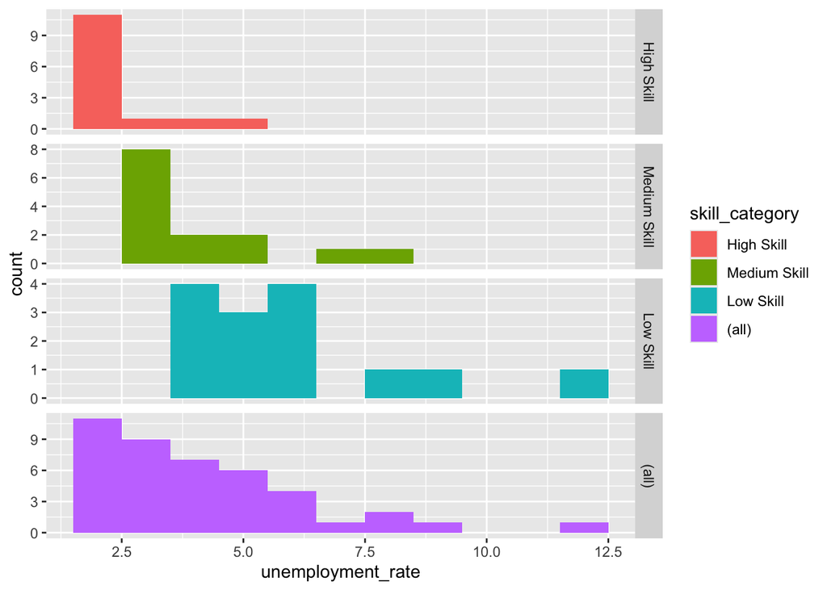

```r
ggplot(education_unemployment, aes(unemployment_rate, fill = skill_category)) + geom_histogram(binwidth = 1) + facet_grid(skill_category ~ ., margins = TRUE, scales = "free")
```

```r
# Perform ANOVA
anova_result <- aov(unemployment_rate ~ skill_category, data = education_unemployment)
summary(anova_result)
```

```
##                Df Sum Sq Mean Sq F value   Pr(>F)
## skill_category  2  83.25   41.62   13.53 3.44e-05 ***
## Residuals      39 119.98    3.08
## ---
## Signif. codes:  0 '***' 0.001 '**' 0.01 '*' 0.05 '.' 0.1 ' ' 1
```

#### Compare unemployment trends over time

Create a multi line graph to see trends over time

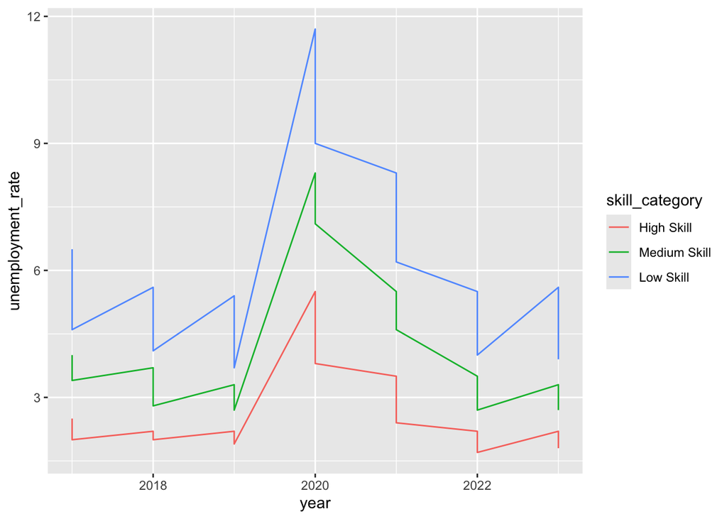

```r
ggplot(education_unemployment, aes(x = year, y = unemployment_rate, color = skill_category)) +
  geom_line()
```

## Report 1.9

The findings align with the research question and theory outlined in the proposal. It makes sense that low-skill workers show greater instability, the boxplots reveal a larger variance in unemployment rates for this group. This supports the idea that low-skill workers are more vulnerable to job loss and displacement compared to higher-skill workers. In the line graph we see the same, but we see specifically in 2020 all the skill categories faced more unemployment, this just shows that lower skill workers experience more problems with unemployment rates when economic changes occur, which potentially means economic changing technology could impact lower skilled workers worse as well

## Report 1.10

The dataset covers only the years 2017–2023, a relatively short period which might not capture long-term trends or gradual technological changes, like AI adoption. This time frame makes it difficult to look at broader trends and understand how unemployment rates evolve over extended periods. Collapsing education levels into skill categories simplifies the analysis. For instance, not all individuals within “Low Skill” or “Medium Skill” groups may experience unemployment similarly some can have certifications and different skills learned outside of school. The ANOVA test shows that there is a statistically significant correlation between skill categories and unemployment rates,but doesn’t say which specific groups are most impacted or provide detailed insights into the level of differences